# Data 624 - Assignment 1

## 3. Retail file

Download some monthly Australian retail data from the book website. These represent retail sales in various categories for different Australian states, and are stored in a MS-Excel file.

### a. You can read the data into R with the following script:

```r
retaildata <- readxl::read_excel("retail.xlsx", skip=1)
```

The second argument (skip=1) is required because the Excel sheet has two header rows.

### b. Time Series Graph data

Select one of the time series as follows (but replace the column name with your own chosen column):

```r
myts <- ts(retaildata[,"A3349640L"],
frequency=12, start=c(1982,4))
```

### c. Time Series Graphs

Explore your chosen retail time series using the following functions: autoplot(), ggseasonplot(), ggsubseriesplot(), gglagplot(), ggAcf()

Can you spot any seasonality, cyclicity and trend? What do you learn about the series?

Data generated on Turnover; Victoria;Cafes, restaurants and catering services

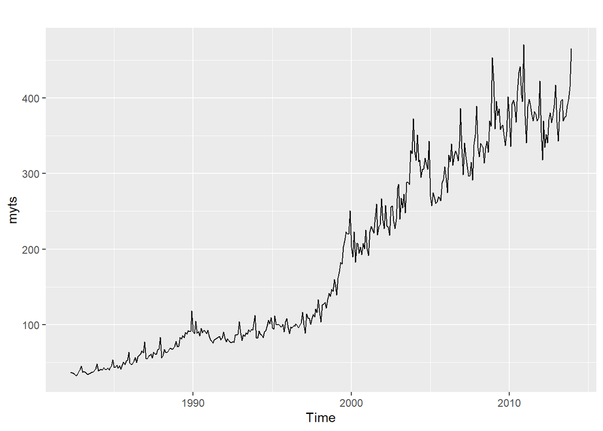

```r
autoplot(myts)
```

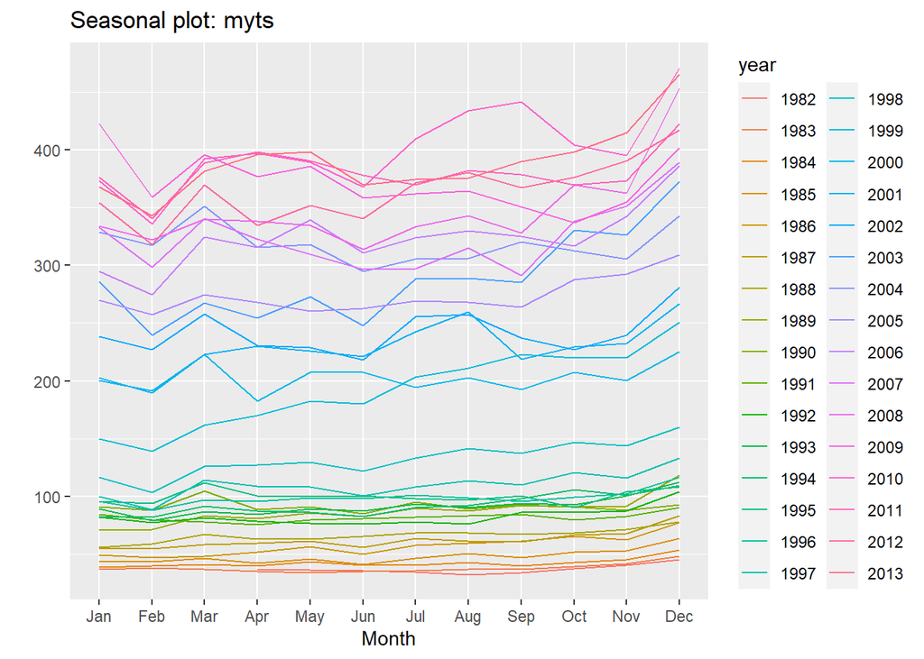

```r
ggseasonplot(myts)
```

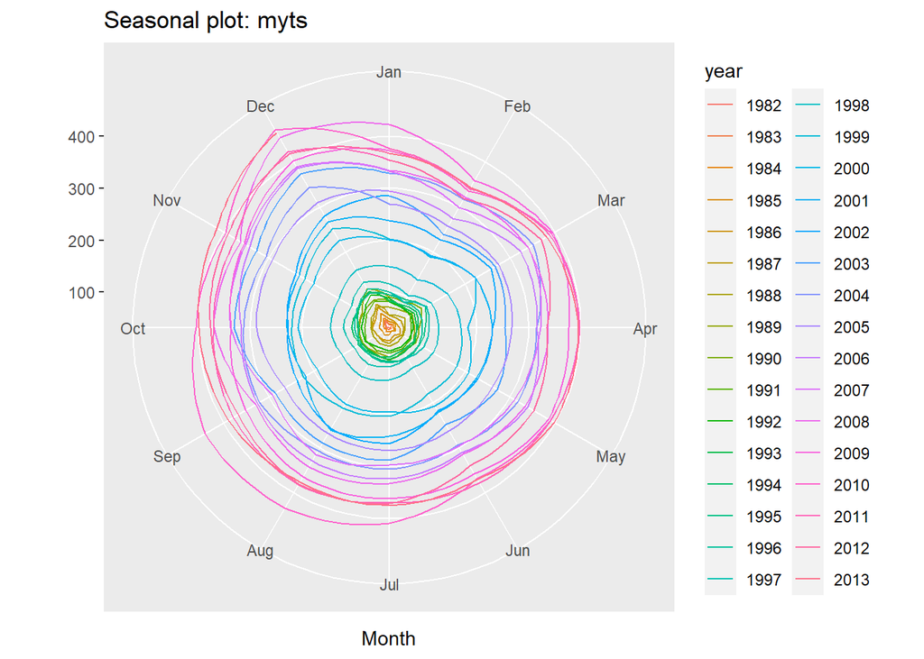

```r
# too many observations to clearly read the non polar graph
ggseasonplot(myts, polar=TRUE)
```

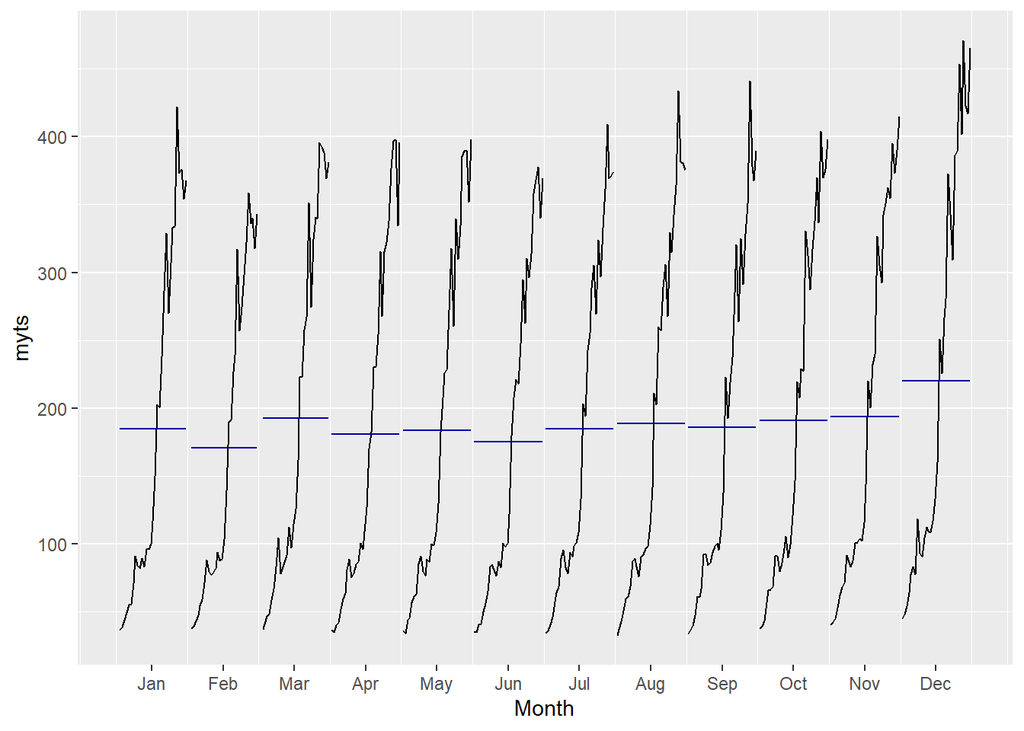

```r
ggsubseriesplot(myts)
```

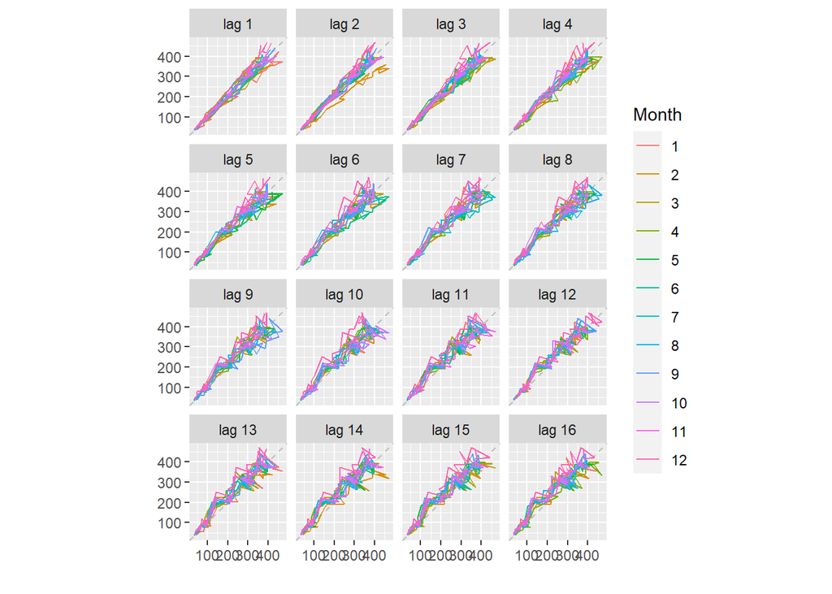

```r
gglagplot(myts)
```

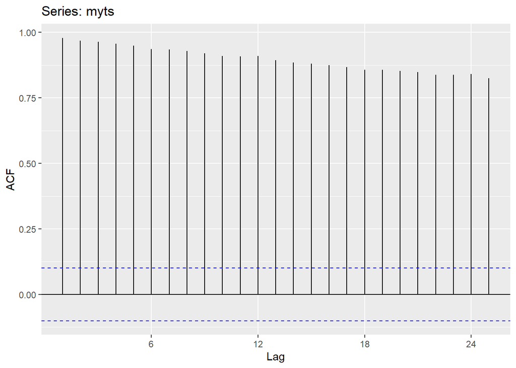

```r
ggAcf(myts)
```

- Between ~1997 and 2000 there is a sharp uptick in values.
  - Before this date the seasonality exists but at a much smaller rate.
  - Further example of a raise in values from around 1997 and up.
- Everything takes a dip in Feb and rises from Nov into Dec
  - Appears to be a very small dip around Jun; potential onset of Winter
  - there is a dip in the mean around the same section
- correlations are significantly different from zero
- Does not appear to have any defined shape of seasonality just a drop over lag

## 6. Use the following graphics functions:

Can you spot any seasonality, cyclicity and trend?  
What do you learn about the series?

### House Sales

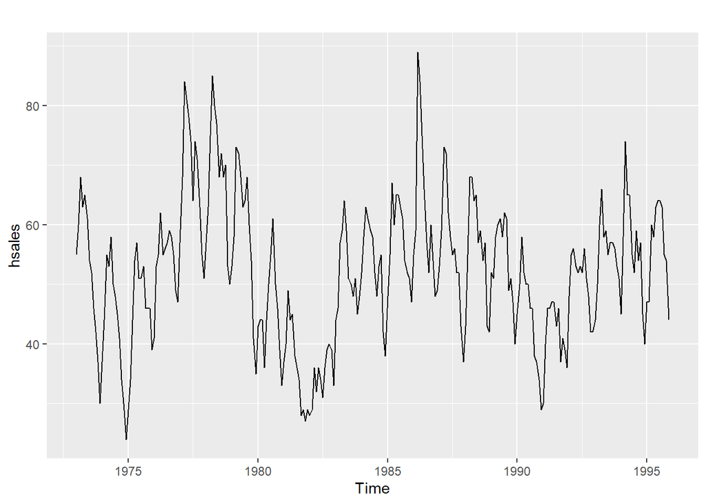

```r
autoplot(hsales)
```

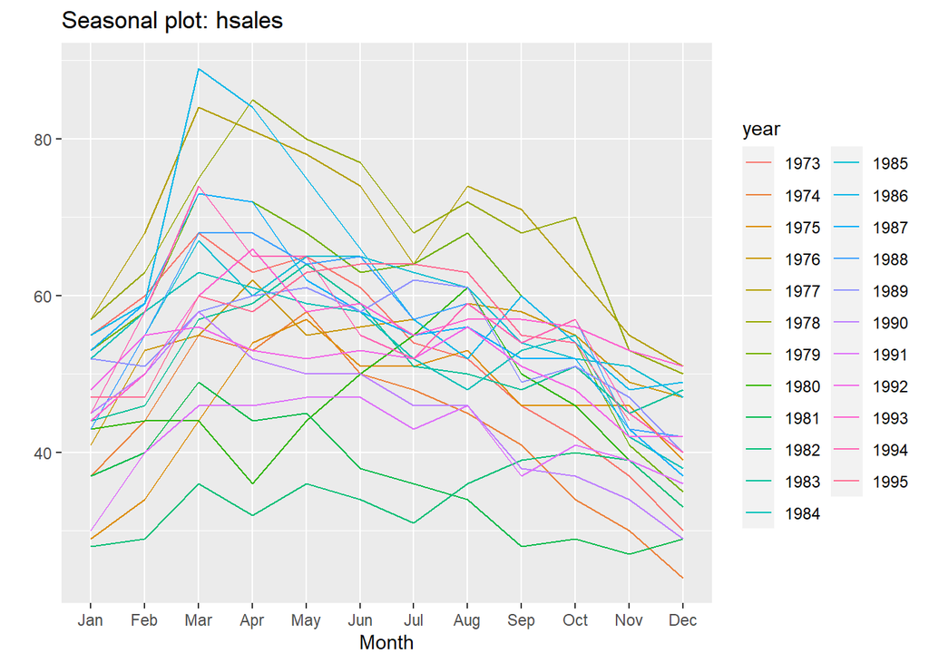

```r
ggseasonplot(hsales)
```

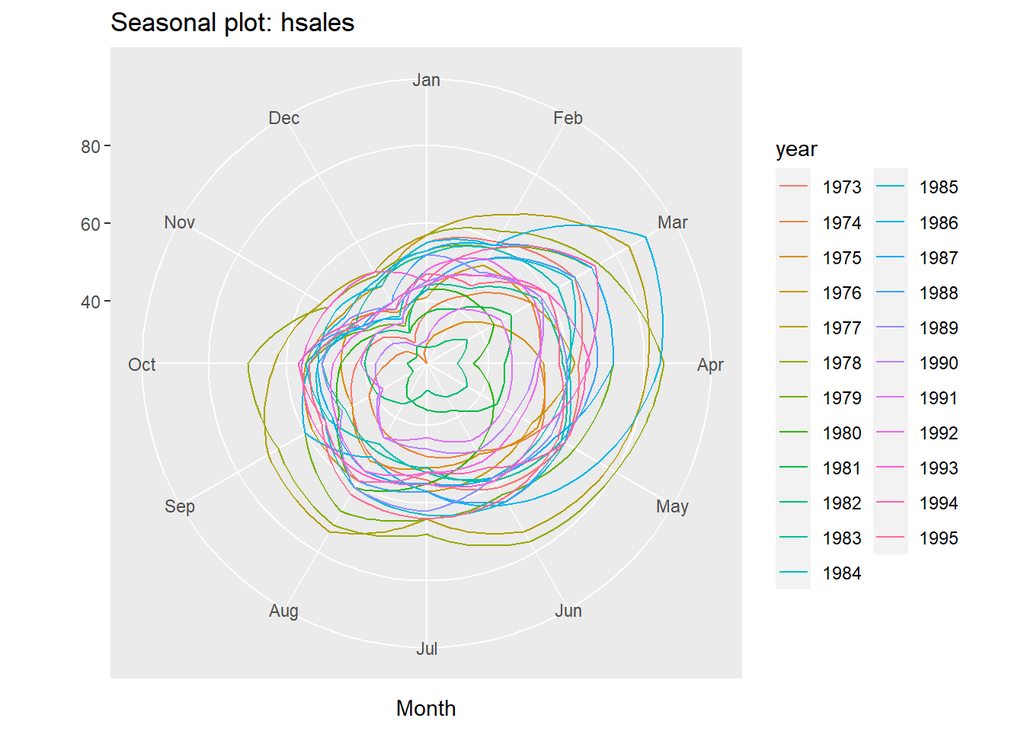

```r
ggseasonplot(hsales, polar = TRUE)
```

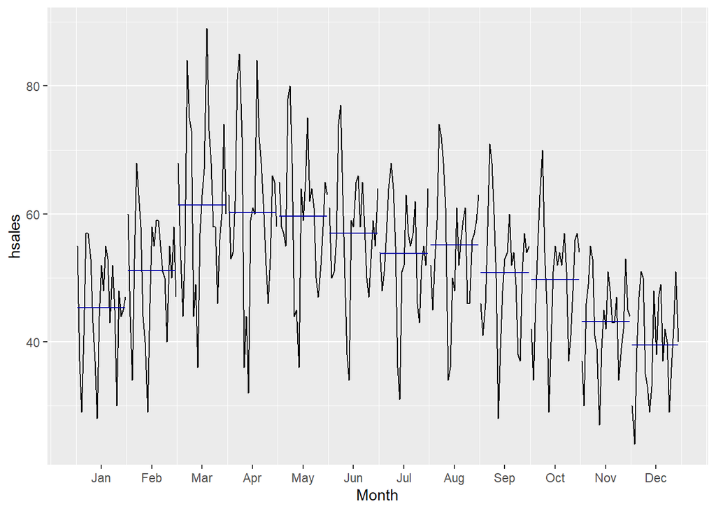

```r
ggsubseriesplot(hsales)
```

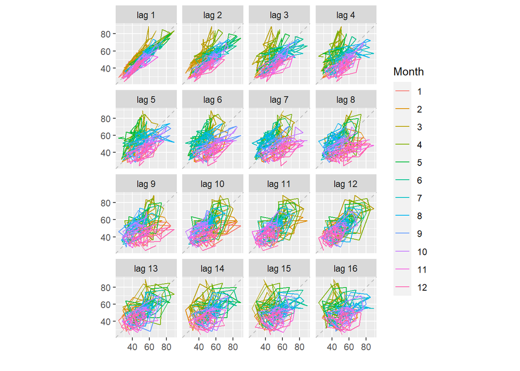

```r
gglagplot(hsales)
```

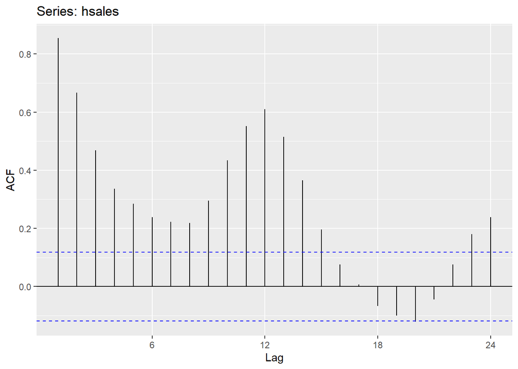

```r
ggAcf(hsales)
```

- There is clear seasonality in home sales starting in March
  - The house buying season starts in Spring aroudn March and tapers off until we get the lowest point around the holidays
- Not sure if we are also seeing cycles or just market factors, (gas shortage 1975, recession 1982-83, etc.)

### US Deaths

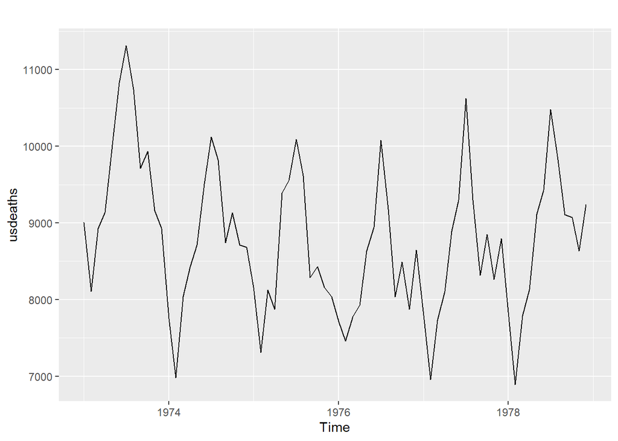

```r
autoplot(usdeaths)
```

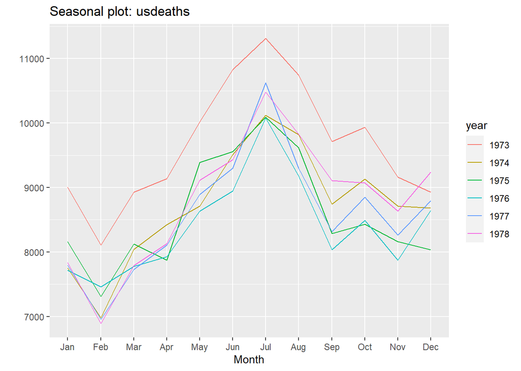

```r
ggseasonplot(usdeaths)
```

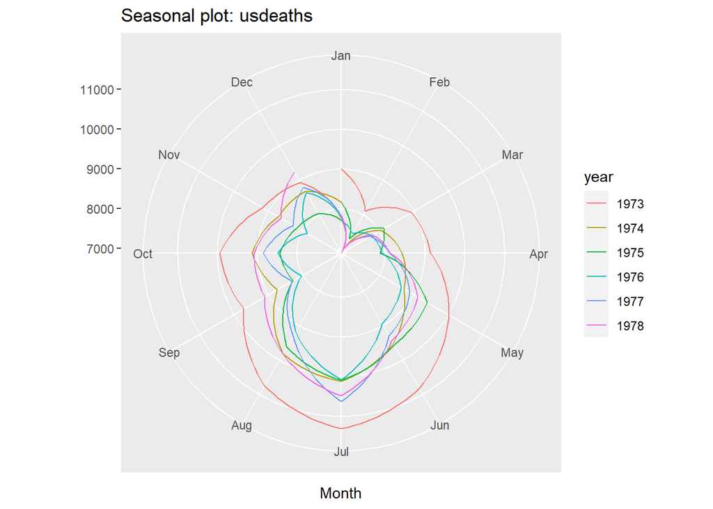

```r
ggseasonplot(usdeaths, polar = TRUE)
```

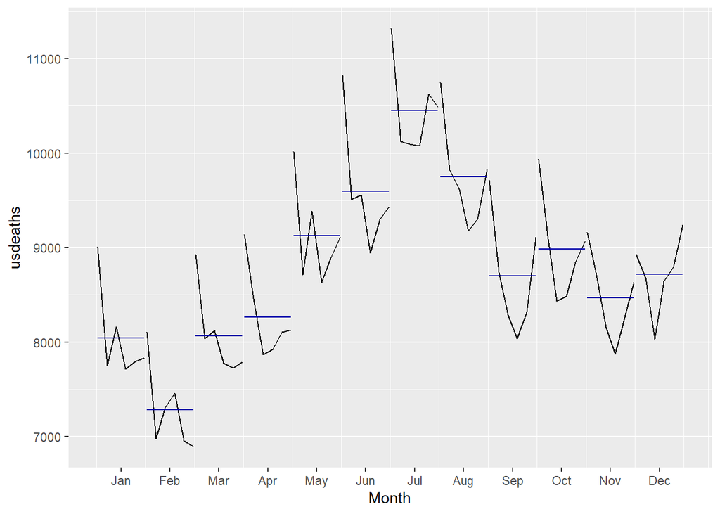

```r
ggsubseriesplot(usdeaths)
```

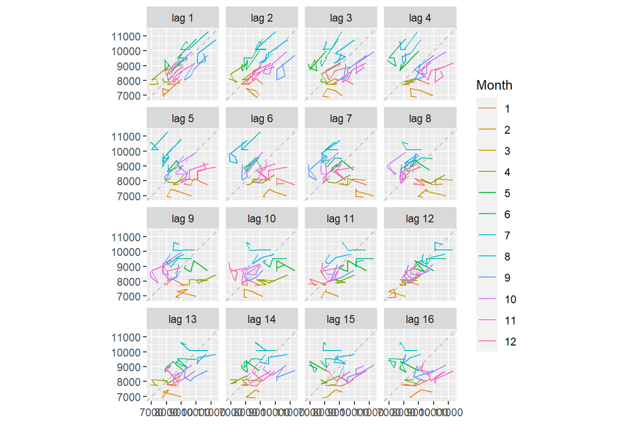

```r
gglagplot(usdeaths)
```

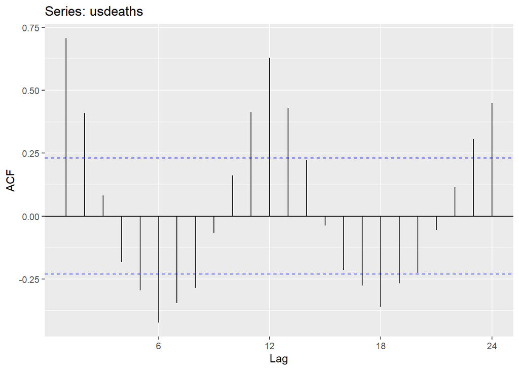

```r
ggAcf(usdeaths)
```

### Quarterly clay brick production

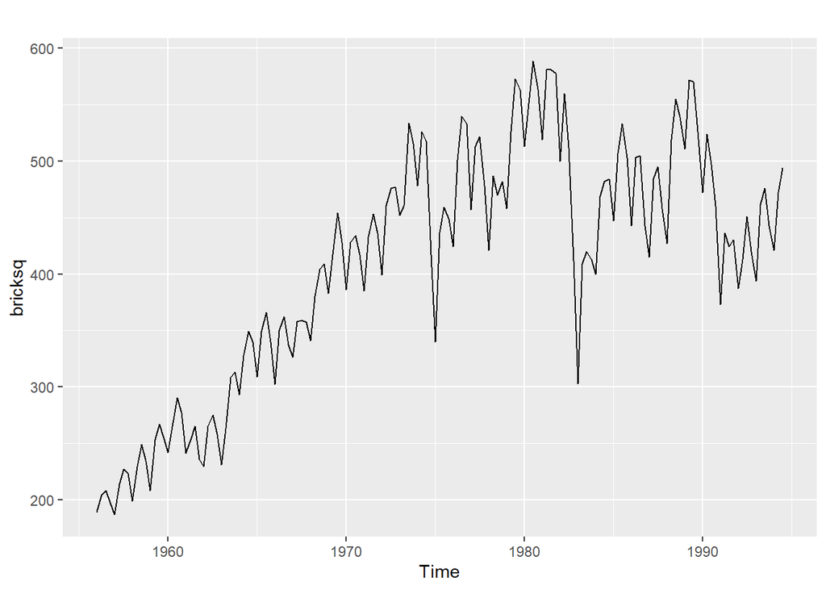

```r
autoplot(bricksq)
```

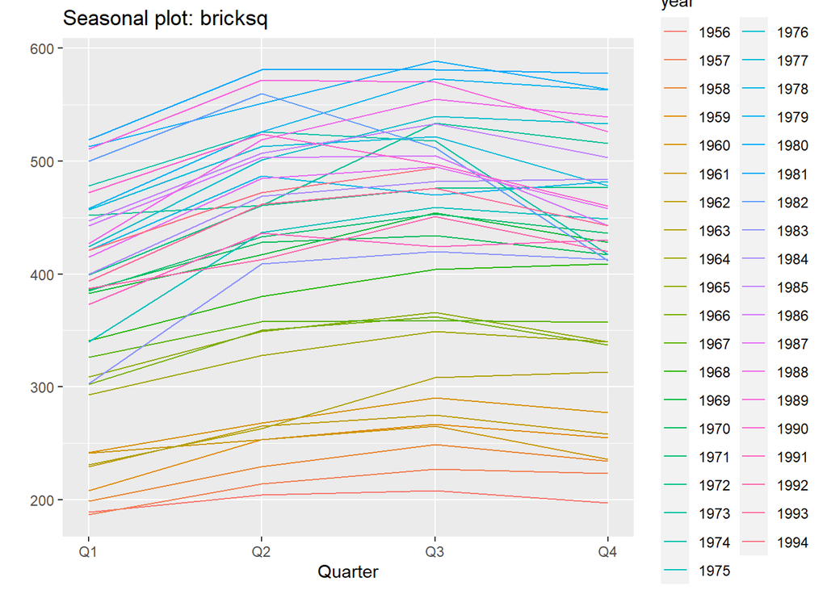

```r
ggseasonplot(bricksq)
```

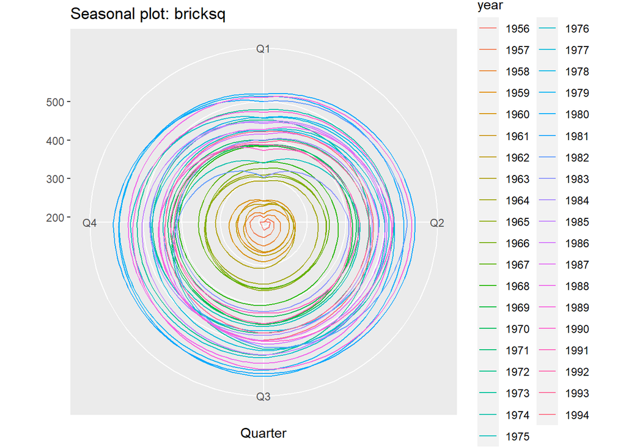

```r
# too many observations to clearly read the non polar graph
ggseasonplot(bricksq, polar=TRUE)
```

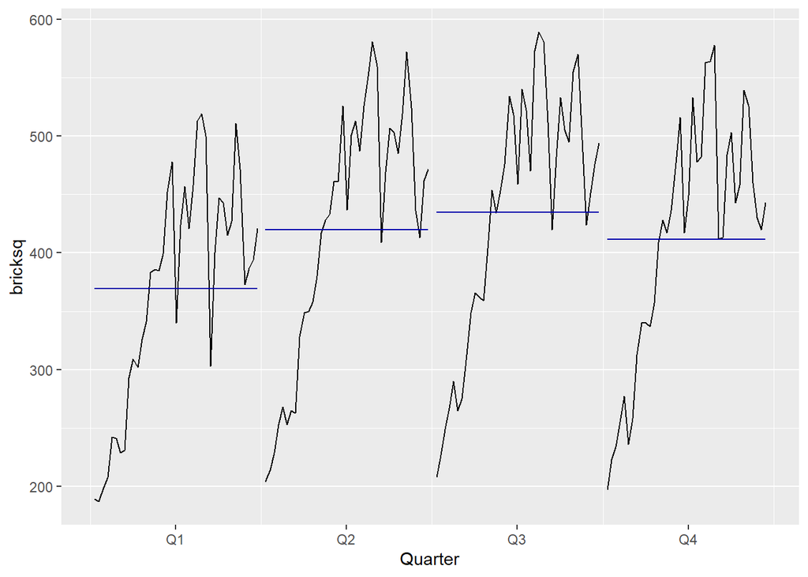

```r
ggsubseriesplot(bricksq)
```

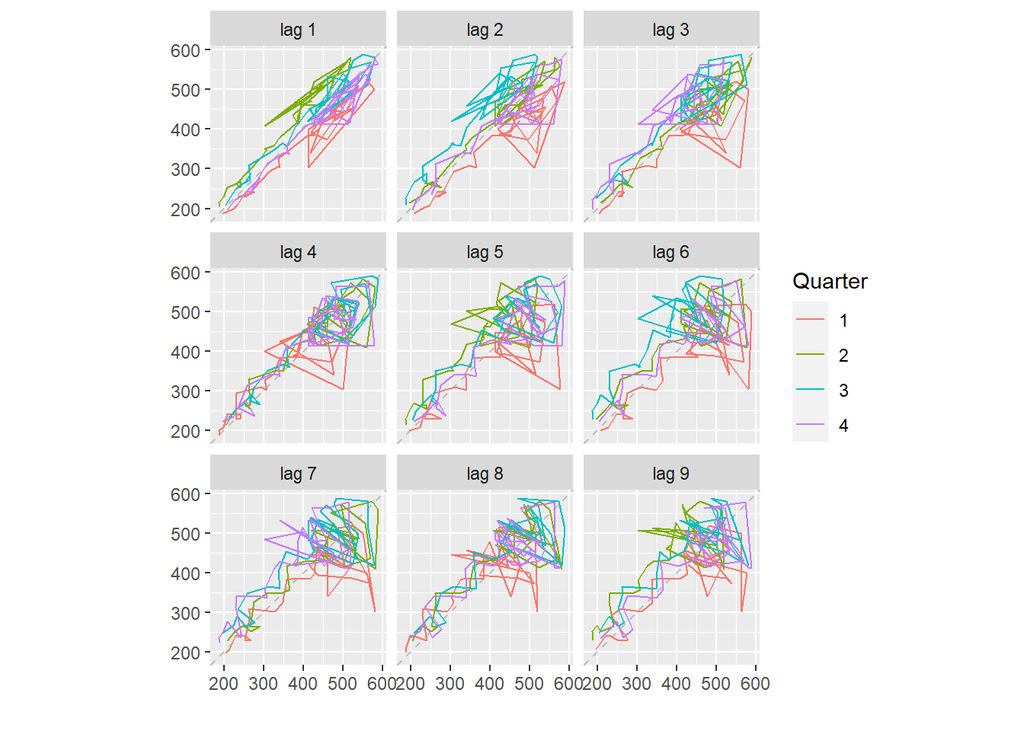

```r
gglagplot(bricksq)
```

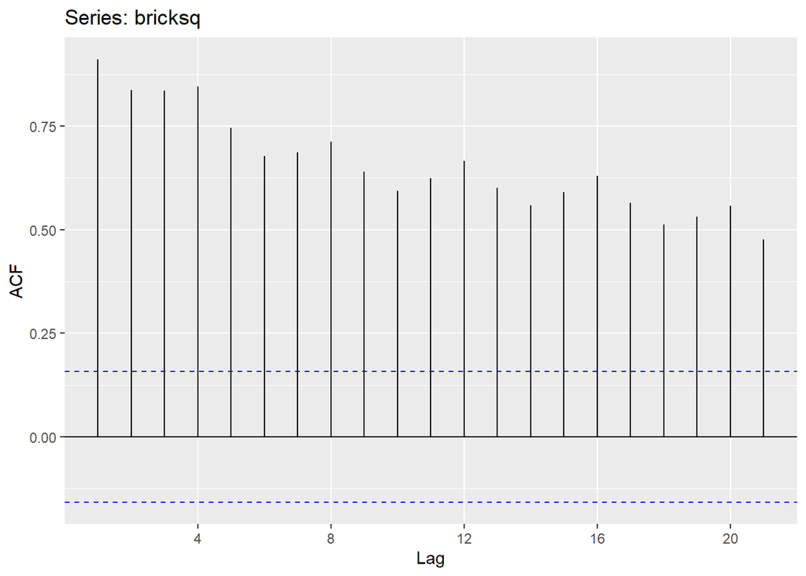

```r
ggAcf(bricksq)
```

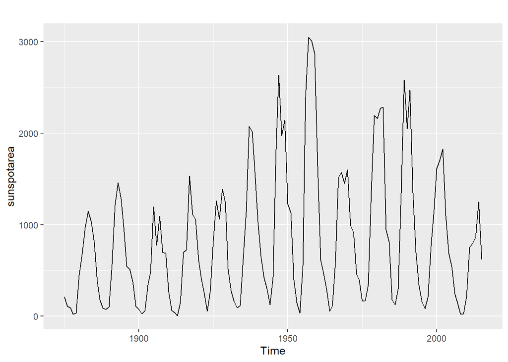

```r
autoplot(sunspotarea)
```

```r
#ggseasonplot(sunspotarea)
```

```r
#ggsubseriesplot(sunspotarea)
```

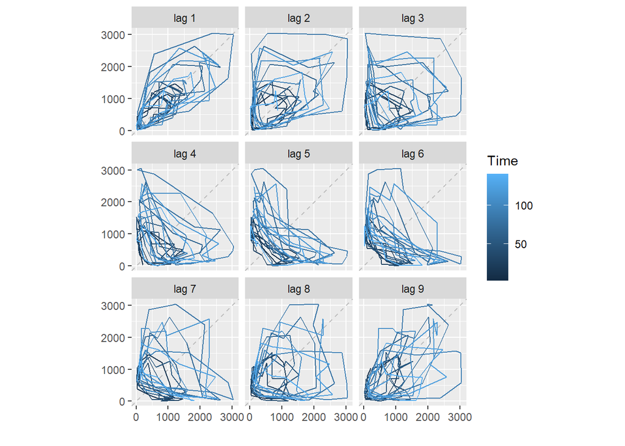

```r
gglagplot(sunspotarea)
```

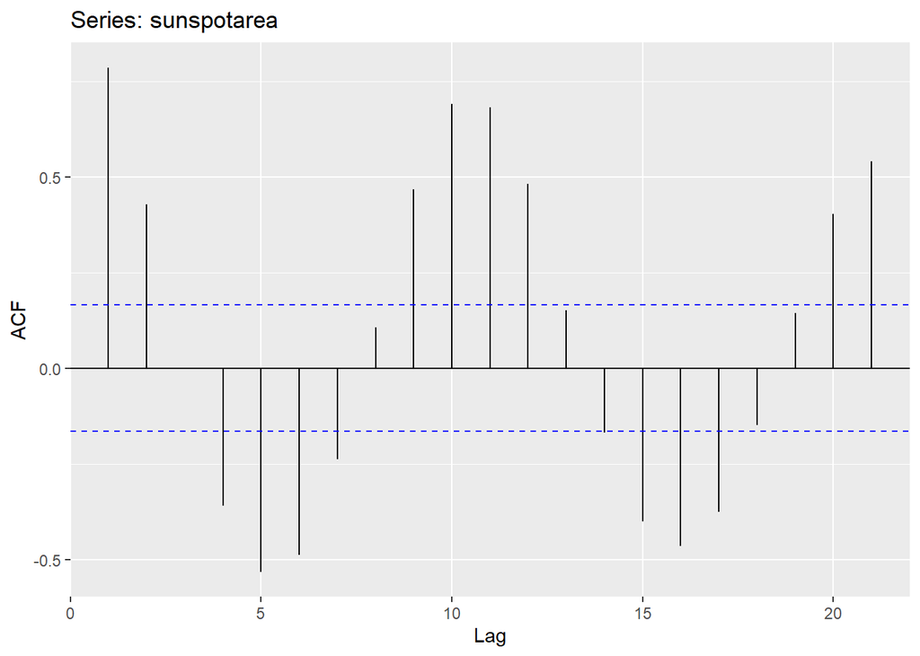

```r
ggAcf(sunspotarea)
```